# A2_Python Analysis Project Individual_Myanganbayar Nyamdavaa

```python
### Python Analysis Project (Individual) Lyft Bay Wheels

from IPython.display import display, HTML

display(HTML("""
<div style="position: relative; text-align: center; color: #2c3e50; font-family:
    Times New Roman;">

  <h1 style="font-size: 40px;">A2: Python Analysis Project (Individual)</h1>

  <p>
    <strong>Student Name:</strong> Myanganbayar Nyamdavaa<br>
    <strong>Instructor:</strong> Prof. Chase Kusterer<br>
    <strong>Course:</strong> Introduction to Python Programming - DAT-5322<br>
    <strong>Institution:</strong> Hult International Business School
  </p>

</div>
"""))

print(f"""
{'-' * 115}\n""")
```

A2: Python Analysis Project (Individual)

**Student Name:** Myanganbayar Nyamdavaa  
**Instructor:** Prof. Chase Kusterer  
**Course:** Introduction to Python Programming - DAT-5322  
**Institution:** Hult International Business School

### 1. Introduction

Ever since its successful rollout a couple of years ago, the bike share service has become an integral part of many people’ lives, serving commuters, tourists, as well as the recreational riders alike. This analysis examines and investigates the different key factors that are driving rental demand, namely, ones associated with weather conditions, time of day, and seasonal trends. Utilizing these datasets, we can uncover key insights that dive into exactly what time of day and why customers choose to ride. To distill these datasets and the insights gained from them, we have created four, distinct, visualizations that map the most active hours of riders, which weather conditions are linked to increased usage, and how seasonality trends affect riders. Each visualization helps to clarify which conditions and timeframes best drive rental usage. By showing these patterns and insights clearly, we can identify practical actionable steps and clear pathways that can be followed to better optimize business processes and strategic decision-making.

```python
# Importing Essential Data

import pandas as pd
import numpy as np
import seaborn as sns
import matplotlib.pyplot as plt

# Importing Dataset from Excel File

file = "bikes_data.xlsx"

biker = pd.read_excel(io  = file,
            sheet_name = 0,
            header     = 0)

print(biker.head(n=10))
```

```
   ID Month Day of Week  Hour  Temperature  Humidity  Wind Speed  Visibility  \
0   1   Jan      Sunday     0         -3.2        40         0.5        1358
1   2   Jan      Sunday    13          2.4        22         2.3        1921
2   3   Jan      Sunday    16          3.0        28         2.5        1864
3   4   Jan      Sunday    17          1.8        33         3.3        1913
4   5   Jan      Sunday    20         -0.3        40         1.2        1936
5   6   Jan      Monday    10         -1.4        50         1.9        1355
6   7   Jan      Monday    18         -0.8        24         2.3        2000
7   8   Jan     Tuesday    21         -4.3        47         2.8        1997
8   9   Jan   Wednesday     3         -7.4        54         1.7        1968
9  10   Jan   Wednesday     7         -8.1        51         0.5        1987

   Dew Point Temperature  UV Index  Rainfall  Snowfall  Season Holiday  \
0                  -14.9      0.00       0.0       0.0  Winter     Yes
1                  -17.2      1.10       0.0       0.0  Winter     Yes
```

[output cut: 20 more lines]

##### Code Explanation - Loading in Data

Imported the essential Python packages and loaded raw dataset from the bikes_data.xlsx Excel file into pandas DataFrame.

```python
print(biker.info())
```

```
<class 'pandas.core.frame.DataFrame'>
RangeIndex: 1387 entries, 0 to 1386
Data columns (total 15 columns):
 #   Column                 Non-Null Count  Dtype
---  ------                 --------------  -----
 0   ID                     1387 non-null   int64
 1   Month                  1387 non-null   object
 2   Day of Week            1387 non-null   object
 3   Hour                   1387 non-null   int64
 4   Temperature            1387 non-null   float64
 5   Humidity               1387 non-null   int64
 6   Wind Speed             1387 non-null   float64
 7   Visibility             1387 non-null   int64
 8   Dew Point Temperature  1387 non-null   float64
 9   UV Index               1387 non-null   float64
 10  Rainfall               1387 non-null   float64
 11  Snowfall               1387 non-null   float64
 12  Season                 1387 non-null   object
 13  Holiday                1387 non-null   object
 14  RENTALS                1387 non-null   int64
dtypes: float64(6), int64(5), object(4)
memory usage: 162.7+ KB
None
```

```python
# Checking for Missing Values

print(biker.isnull().sum())
```

```
ID                       0
Month                    0
Day of Week              0
Hour                     0
Temperature              0
Humidity                 0
Wind Speed               0
Visibility               0
Dew Point Temperature    0
UV Index                 0
Rainfall                 0
Snowfall                 0
Season                   0
Holiday                  0
RENTALS                  0
dtype: int64
```

```python
# Checking Summary Values

print(biker.describe())
```

```
                ID         Hour  Temperature     Humidity   Wind Speed  \
count  1387.000000  1387.000000  1387.000000  1387.000000  1387.000000
mean    694.000000    11.553713    13.093511    58.759193     1.707714
std     400.536723     6.924075    11.902220    20.559202     1.019488
min       1.000000     0.000000   -15.800000    11.000000     0.000000
25%     347.500000     6.000000     3.200000    43.000000     0.900000
50%     694.000000    12.000000    14.100000    58.000000     1.500000
75%    1040.500000    18.000000    22.800000    75.000000     2.300000
max    1387.000000    23.000000    38.000000    98.000000     7.400000

        Visibility  Dew Point Temperature     UV Index     Rainfall  \
count  1387.000000            1387.000000  1387.000000  1387.000000
mean   1434.423216               4.365537     0.573338     0.139005
std     618.087288              13.100902     0.869165     1.262159
min      81.000000             -30.500000     0.000000     0.000000
25%     946.000000              -4.400000     0.000000     0.000000
50%    1718.000000               5.200000     0.010000     0.000000
75%    2000.000000              15.600000     0.975000     0.000000
max    2000.000000              26.600000     3.450000    35.000000

          Snowfall      RENTALS
count  1387.000000  1387.000000
mean      0.079813   810.015862
std       0.444182   694.720990
min       0.000000     5.000000
25%       0.000000   250.500000
50%       0.000000   626.000000
75%       0.000000  1196.500000
max       7.000000  3734.000000
```

##### Code Explanation - Checking Data Quality & Summary

First, I verified that there were no missing values and checked the basic distribution of all values. This is done to verify that there is complete data across all columns. .Describe() was used to identify key metrics for understanding the components of the values.

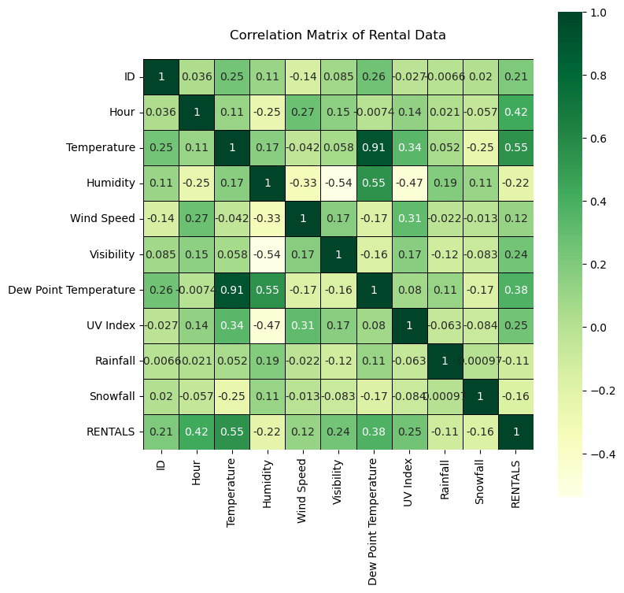

```python
## Creating a Correlation Matrix Heat map for all Rental Data

fig, ax = plt.subplots(figsize = (8 , 8))

# Generating the Heat map
sns.heatmap(data = bikes_corr,
            cmap = 'YlGn',
            square = True,
            annot = True,
            linecolor = 'black',
            linewidths = 0.5
            )

# Title Label
plt.title(label = """
Correlation Matrix of Rental Data
""")

# Displaying the Map
plt.show(block = True)
```

#### 2.1 Correlation Matrix of Rental Data

The correlation matrix is a strong visualization to examine first, as it illustrates the strength of relationship between all the values, and can help identify which factors are most tied to rental numbers. “Temperature” has the strongest link with higher rentals, while “Hour” also shows a moderate connection. “Humidity” and “Snowfall” show a negative relationship with usage, and “Dew Point” moves with “Temperature”, which means riders respond more to how the weather feels. These findings help in focusing on demand forecasting on weather, especially temperature. According to an article titled, "Weather impact on bike-sharing demand..." from ScienceDirect, temperature, humidity, and wind speeds were found to be consistent and reliable predictors of the behavioral changes in bike rental demand (Bean et al., 2021).

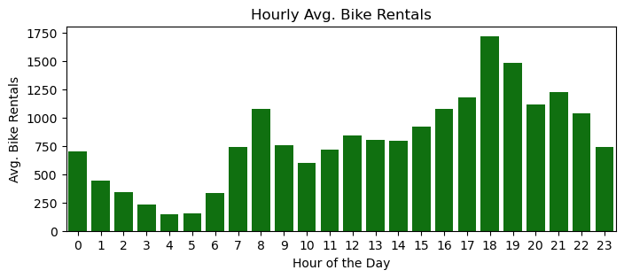

```python
## Creating Bar chart for Hourly Avg. Bike Rentals Data

plt.figure(figsize=(8, 3))
sns.barplot(data=biker, x='Hour', y='RENTALS', errorbar=None, color = "green")

# Title and Axes Labels
plt.title('Hourly Avg. Bike Rentals')
plt.xlabel('Hour of the Day')
plt.ylabel('Avg. Bike Rentals')

# Displaying the Chart
plt.show()
```

#### 2.2 Hourly Average Bike Rentals

Looking at the hourly average bike rentals is important in identifying the peak time frames in which customers frequently use our services. It shows two clear peaks during the morning (7–9 AM), and late afternoon (4–6 PM), which are primarily commuting hours. Usage drops heavily between the times of midnight and 5 AM, showing low demand at night. Midday rentals stay steady but lower, most likely due to casual use from recreational riders or flexible students. This analysis confirms that most riders are utilizing our bikes to get to and from work. These findings suggest that adjustments to staff shifts and bike availability to service the demand during these times can improve overall usage and service.

##### Code Explanation - Identifying Relationships & Patterns in Rentals

The correlation heat map shows that Hour and Temperature are the strongest drivers of rental figures. Translated into a bar chart, the hour chart shows that there are distinct peaks in early morning and late afternoon, during commuting hours.

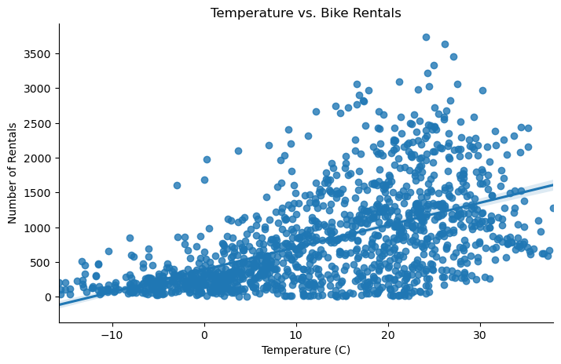

```python
## Creating Scatter plot of Temperature and Rentals

sns.lmplot(x   = 'Temperature',
           y   = 'RENTALS',
           scatter  = True,
           fit_reg  = True,
           aspect   = 1.5,
           data     = biker)

# Title and Axes Labels
plt.title(label   = 'Temperature vs. Bike Rentals')
plt.xlabel(xlabel = 'Temperature (C)')
plt.ylabel(ylabel = 'Number of Rentals')
plt.xlim(left  = biker['Temperature'].min(),
         right = biker['Temperature'].max())
plt.tight_layout(pad = 2)

# Displaying the Plot
plt.show(block = True)
```

#### 2.3 Temperature vs. Bike Rentals

Since the correlation matrix suggested a strong link between temperature and rentals, it is important to note how, exactly. The graph shows that as temperature rises, rentals go up quickly, until roughly 20’C, where there is a relative dropoff. The strongest increases occur in the mild to warm range, and very hot days show a slight decrease in use, most likely attributable to discomfort. This analysis of the temperature and rentals scatter plot confirms that there is an existence of a temperature “comfort zone” for riders. Furthermore, the article titled, "How Do Weather and Season Affect Bike Rentals?" by Bobby Chandra reinforces that the 15-25'C range is one that has shown the highest number of rides from customers (Chandra, 2021). Moving forward, the trends shown can guide and inform business decisions on promotions or pricing tied to weather.

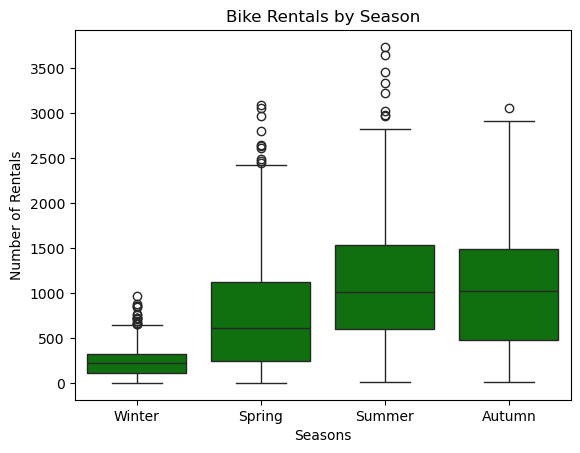

```python
## Creating a Box plot for Season and Rentals

sns.boxplot(x    = 'Season',
            y    = 'RENTALS',
            data = biker,
            color='green')

# Title and Axes Labels
plt.title(label   = 'Bike Rentals by Season')
plt.xlabel(xlabel = 'Seasons')
plt.ylabel(ylabel = 'Number of Rentals')

# Displaying the Plot
plt.show(block = True)
```

#### 2.4 Bike Rentals by Season

Looking at specific seasonality differences in rider preference and changes can be a significant insight, especially as it pertains to promotions and pricing. The box plot shows that Summer has the highest rentals with the most variation, then followed by Autumn and Spring. Winter, on the other hand, shows the lowest usage with the least change daily. Some Spring and Summer days spikes can be observed well above the average. These seasonal analyses illustrate when to scale up bike supplies and adjust marketing in promotional offers. Planning around these cycles in the box plot can improve both business operations and sales performance.

### 3. Analysis Questions

When looking at all of the insights gleaned so far, they illustrate a clear path in optimizing strategies. Firstly, the active number of staff and bikes available should be concentrated around the mornings and evenings during workweeks to better serve customers while they are commuting. Secondly, promotions should targeted and sent out during dry, mild days with a mixture of loyalty offers and discounts. Promotional offers should also be utilized during the slower times of midday, to better seize customers wanting to travel. Thirdly, seasonal analyses show that bikes and possibly higher pricing can be justified during Summer when rentals are highest, while discounts and deals can help keep users active during the Winter months when rentals are lowest. Lastly, weather data like rain and humidity should guide real-time alerts and rider nudges on a frequent basis. Operations and marketing that is tied to timing and weather conditions will drastically improve availability, boost rentals, and increase customer satisfaction.

### 4. Conclusion

Bike rentals and bikesharing services remain a popular choice for individuals in all ranges of groups, but the overarching analyses illustrate that the rentals are primarily used for commuting to and from their place of work or studies. The significant timeframes where most rides occur have been identified to better promote marketing efforts, and weather, seasonal, and temperature analyses have been conducted to streamline operations more effectively. Based on these analyses, operations should be adjusted to match demand windows and maintenance should focus on keeping bikes ready during high-demand periods. Marketing and pricing should follow the same trends. In peak months, higher pricing may be reasonable, while slower seasons could use deals to boost activity.By aligning operations and business strategy with clear usage patterns and trends, the bikes can remain to be a top solution for all groups of riders.

### 5. References Cited

Bean, R., Pojani, D., & Corcoran, J. (2021, August 13). How does weather affect bikeshare use? A comparative analysis of forty cities across climate zones. Journal of Transport Geography. https://www.sciencedirect.com/science/article/abs/pii/S0966692321002088 Chandra, B. (2021, June 18). How do weather and season affect bike rentals?. Medium. https://bobby-js-chandra.medium.com/how-do-weather-and-season-affect-bike-rentals-d26164e3233b